# Imputation of Missing Body Sizes in Parasites

Daniel Smith

17 April 2019

## Missing Data Structure

Before we move further with imputation of missing values it’s important to understand the overall structure of data and the missing values present within that.

### Visualising Missing Data for SSA

Load the required packages.

```r
library(tidyverse) # general data wizadry and manipulation
library(VIM) # visualise missing data patterns
library(naniar) # data structure visualisation in a 'tidy' manner
library(visdat) # accompanies the naniar package

# set environment
rm(list=ls()) # remove all objects
set.seed(12) # set the random seed to 12 so results are reproducible
```

First we need to read in the required data from a GitHub repositary. For this methods demonstration we will just use the BSQ subportion of the Carpinteria foodweb as an example. The process is exactly the same for all foodwebs.

```r
bsq <- read.csv("https://raw.githubusercontent.com/SmithD19/FoodWeb/master/data/interactionwebdb/Carpinteria/BSQweb_Nodes.csv") # load data from GitHub repo - simple
```

A plot below using the `visdat` library allows us to visualise this further and gives more information about overall data structure and the type of data.

```r
# Overall data structure and missing values using visdat library
vis_dat(bsq) +
  labs(title = "Structure and NA values of BSQ data")
```

[figure not shown]

We can clearly see the NA values in the data frame here marked by the grey blocking. This also makes it easy for us to select only the values we care about for imputation, the trait values and give them better, easier to write names in a new and less cluttered data frame.

```r
bsq_wrk <-
  bsq %>% # select and rename some variables
  dplyr::select(FunctionalGroup = ConsumerStrategy.stage., BodySize = BodySize.g.,
                Biomass = Biomass.kg.ha., Abundance = Abundance.no..ha.) %>%
  mutate(BodySize = BodySize / 1000) # change BodySize from g to Kg so that units are equal
```

Using the handy VIM package we can quickly visualise the missing data present in the original data set - in particular the trait values of the nodes are what we’re interested in for now.

```r
aggr(bsq_wrk[,2:4], col=c('navyblue','red'),
                 numbers=TRUE, sortVars=TRUE, labels=names(bsq_wrk[, 2:4]),
                 cex.axis=.7, gap=3, ylab=c("Missing Data Histogram for BSQ","Pattern of Missing Data for BSQ"))
```

[figure not shown]

Using the equation $Biomass = BodySize * Abundance$ we can conditionally fill in variables that are missing from data points using `mutate()` and `case_when()`. Below is the workflow used for conditionally replacing this data based on the equation and reassembling the data back to it’s original structure but containing the new values inferred from the equation above.

```r
bsq_new <-
  bsq_wrk %>%
  ## if BodySize = NA & if Biomass & Abundance != NA then BodySize = Biomass/Abundance
  mutate(BodySizeNew = case_when(!is.na(Abundance & Biomass) ~ Biomass / Abundance),
         ## if Abundance = NA and BodySize & Biomass != NA then Abundance = Biomass/BodySize
         AbundanceNew = case_when(!is.na(BodySize & Biomass) ~ Biomass / BodySize),
         ## if Biomass = NA and BodySize & Abundance != NA then Biomass = Abundance * BodySize
         BiomassNew = case_when(!is.na(Abundance & BodySize) ~ Abundance * BodySize)) %>%
  ## join the columns of new and old together use coalesce -- Biomass + BiomassNew...
  ## this selects the original value first so only values that are missing from original dataset and then computed are selected
  mutate(BodySize_Work = coalesce(BodySize, BodySizeNew),
         Biomass_Work = coalesce(Biomass, BiomassNew),
         Abundance_Work = coalesce(Abundance, AbundanceNew)) %>%
  ## now dplyr::select and rename the new working colums to replace the old incomplete data set
  dplyr::select(FunctionalGroup, BodySize = BodySize_Work,
                Biomass = Biomass_Work, Abundance = Abundance_Work)
```

Now with the extra values we added from the inferred relationship between BodySize, Biomass and Abundance we can look at how much data we have to work with when getting ready for the imputation process.

First lets take a look at another plot using the VIM `aggr` plotting function.

```r
aggr(bsq_new[,2:4], col=c('navyblue','red'),
     numbers=TRUE, sortVars=TRUE, labels=names(bsq_new[, 2:4]),
     cex.axis=.7, gap=3, ylab=c("Histogram of missing data for BSQ","Pattern of missing data for BSQ"))
```

[figure not shown]

Now it looks like we have 75% of the data with no missing values for any of that traits we’re interested in. This is significantly better than the 50% we had earlier and gives us a better starting point for the imputation process using the `mice` package, which is shorthand for Multivariate Imputation using Chained Equations.

## Imputation

For imputation we have the choice of several packages in the CRAN repository. For now the most appropriate package is that of `mice` as shown by penone, without phylogenetic data this method provides the best impuation results, particularly for body size data and traits highly correlated to this.

```r
library(mice) # R package for Multivariate Imputation using Chained Equations
# Be aware that the MASS package attatched to mice masks the select() function by dplyr
# It is therefore necessry to specifically call dplyr::select() to use this function
```

Lets create a new data frame for the imputation process. It’s important in the imputation process to log transform values that could be correlated with each otehr, this process reduces the co-linearity of the values and therefore makes imputation more accurate.

```r
bsq_imp <- bsq_new %>% dplyr::select(BodySize, Biomass, Abundance) %>%
  ##  log transform the variables you want to impute, addition of 1 solves problems
  ##  with infinite results due to logging values below 0
  mutate(BodySize = log(BodySize + 1), Biomass = log(Biomass + 1), Abundance = log(Abundance + 1))
```

```r
bsq_imp <- mice(bsq_imp, m = 5, method = "pmm")
```

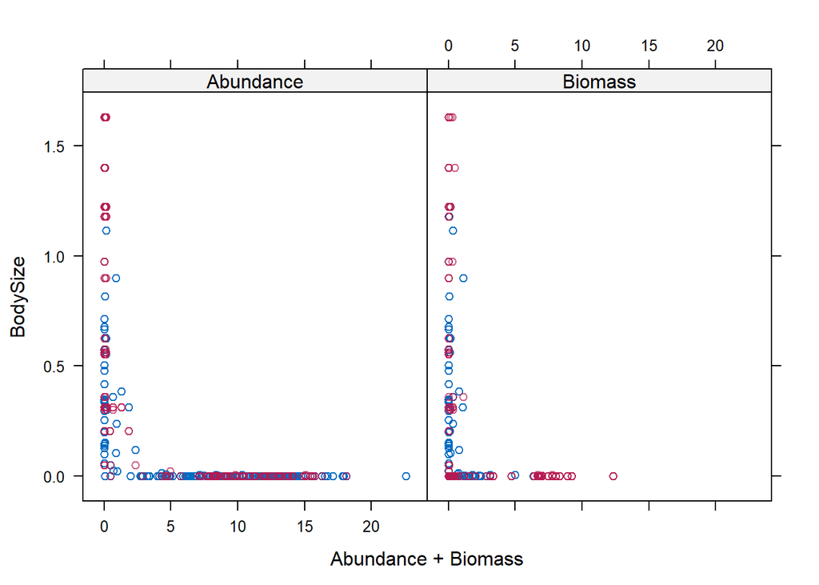

```r
xyplot(bsq_imp, BodySize ~ Abundance + Biomass)
```

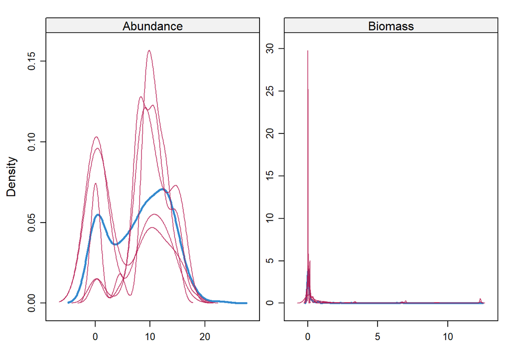

```r
densityplot(bsq_imp, BodySize ~ Abundance + Biomass)
```

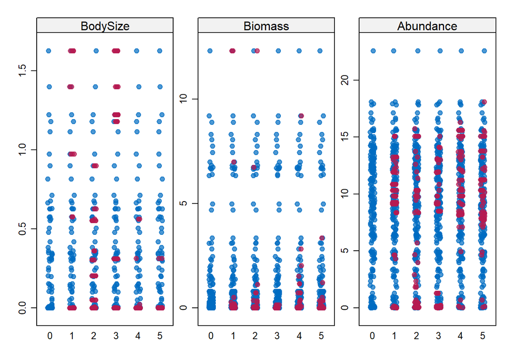

```r
stripplot(bsq_imp, pch = 20, cex = 1.2)
```

```r
bsq_imp <- complete(bsq_imp)
```